# Capstone

Author

Andee Garcia

```r
library(haven)
library(tidyverse)
library(fastDummies)
Capstone <- read.csv("/Users/andeegarcia/Desktop/DATASCIENCE2/capstonedata.csv")

Capstone_22 <- Capstone %>%
  drop_na(degree22)
```

**Modeling people who graduated and received a degree in 2022 (degree22) as a function of financial aid (aid22), loans (loans22), and library circulations (library2022)**

```r
m1 <- glm(degree22 ~ aid22 + loans22 + library2022,
         data = Capstone)
summary(m1)
```

```
Call:
glm(formula = degree22 ~ aid22 + loans22 + library2022, data = Capstone)

Coefficients:
              Estimate Std. Error t value Pr(>|t|)
(Intercept) -3.976e+02  1.539e+02  -2.583 0.011271 *
aid22        7.048e-02  1.788e-02   3.943 0.000151 ***
loans22      4.457e-01  7.400e-02   6.023 2.99e-08 ***
library2022  1.146e-04  2.807e-05   4.083 9.10e-05 ***
---
Signif. codes:  0 '***' 0.001 '**' 0.01 '*' 0.05 '.' 0.1 ' ' 1

(Dispersion parameter for gaussian family taken to be 1627048)

    Null deviance: 621148201  on 101  degrees of freedom
Residual deviance: 159450705  on  98  degrees of freedom
  (29 observations deleted due to missingness)
AIC: 1754.2

Number of Fisher Scoring iterations: 2
```

```r
coefficients(m1)
```

```
  (Intercept)         aid22       loans22   library2022
-3.975599e+02  7.048052e-02  4.456919e-01  1.145949e-04
```

$$Degree22=-397.5599+0.0704x_1+0.4457x_2+.0001x_3$$

**95% confidence intervals for the regression coefficients.**

```r
confint(m1)
```

```
                    2.5 %        97.5 %
(Intercept) -6.992219e+02 -9.589797e+01
aid22        3.544386e-02  1.055172e-01
loans22      3.006604e-01  5.907233e-01
library2022  5.958064e-05  1.696092e-04
```

95% CI for $\beta_{aid22}$ is (0.0354, 0.1055)

95% CI for $\beta_{loans22}$ is (0.3006, 0.5907)

95% CI for $\beta_{library2022}$ is (0.00005, 0.00016)

**Hypothesis and conclusion on if the regression line holds significance at the $\alpha=0.05$ level**

```r
m2 <- lm(degree22 ~ aid22 + loans22 + library2022,
         data = Capstone)
summary(m2)
```

```
Call:
lm(formula = degree22 ~ aid22 + loans22 + library2022, data = Capstone)

Residuals:
    Min      1Q  Median      3Q     Max
-4413.9  -215.9   216.6   364.6  4837.9

Coefficients:
              Estimate Std. Error t value Pr(>|t|)
(Intercept) -3.976e+02  1.539e+02  -2.583 0.011271 *
aid22        7.048e-02  1.788e-02   3.943 0.000151 ***
loans22      4.457e-01  7.400e-02   6.023 2.99e-08 ***
library2022  1.146e-04  2.807e-05   4.083 9.10e-05 ***
---
Signif. codes:  0 '***' 0.001 '**' 0.01 '*' 0.05 '.' 0.1 ' ' 1

Residual standard error: 1276 on 98 degrees of freedom
  (29 observations deleted due to missingness)
Multiple R-squared:  0.7433,    Adjusted R-squared:  0.7354
F-statistic: 94.59 on 3 and 98 DF,  p-value: < 2.2e-16
```

$H_0 : \beta_{aid22} = \beta_{loans22} = \beta_{library2022} = 0$

$H_1 : \text{at least one } \beta_i \neq0$

Reject $H_0$ if p<0.05

The p-value <0.001, thus we reject $H_0$. There is sufficient evidence to suggest that at least one slope is non-zero which means the regression line holds significance.

**Significant predictors on the number of graduates at the $\alpha=0.05$ level.**

```r
summary(m2)
```

```
Call:
lm(formula = degree22 ~ aid22 + loans22 + library2022, data = Capstone)

Residuals:
    Min      1Q  Median      3Q     Max
-4413.9  -215.9   216.6   364.6  4837.9

Coefficients:
              Estimate Std. Error t value Pr(>|t|)
(Intercept) -3.976e+02  1.539e+02  -2.583 0.011271 *
aid22        7.048e-02  1.788e-02   3.943 0.000151 ***
loans22      4.457e-01  7.400e-02   6.023 2.99e-08 ***
library2022  1.146e-04  2.807e-05   4.083 9.10e-05 ***
---
Signif. codes:  0 '***' 0.001 '**' 0.01 '*' 0.05 '.' 0.1 ' ' 1

Residual standard error: 1276 on 98 degrees of freedom
  (29 observations deleted due to missingness)
Multiple R-squared:  0.7433,    Adjusted R-squared:  0.7354
F-statistic: 94.59 on 3 and 98 DF,  p-value: < 2.2e-16
```

$H_0 : \beta_{i} = 0$

$H_1 : \beta_{i} \neq0$

Reject $H_0$ if p<0.05

The p-value <0.001 for all predictors, thus we reject $H_0$. There is sufficient evidence to suggest that financial aid, Student loans, and Library circulations significantly predicts graduation numbers for the year 2022.

**Brief interpretations for the slopes of the predictors.**

$$Degree22=-397.5599+0.0704x_1+0.4457x_2+.0001x_3$$

For every one increase in financial aid, we expect an increase of 0.0704 in graduation numbers. NOTE: not as significant as other variables

For every one increase in Library circulation, we expect an increase of 0.0001 in graduation numbers.

**Suspected outliers that exist**

```r
Capstone_22 <- Capstone %>%
  select(degree22, aid22, loans22, library2022) %>%
  na.omit()

m3 <- glm(degree22~aid22+loans22+library2022, data=Capstone_22)
summary(m3)
```

```
Call:
glm(formula = degree22 ~ aid22 + loans22 + library2022, data = Capstone_22)

Coefficients:
              Estimate Std. Error t value Pr(>|t|)
(Intercept) -3.976e+02  1.539e+02  -2.583 0.011271 *
aid22        7.048e-02  1.788e-02   3.943 0.000151 ***
loans22      4.457e-01  7.400e-02   6.023 2.99e-08 ***
library2022  1.146e-04  2.807e-05   4.083 9.10e-05 ***
---
Signif. codes:  0 '***' 0.001 '**' 0.01 '*' 0.05 '.' 0.1 ' ' 1

(Dispersion parameter for gaussian family taken to be 1627048)

    Null deviance: 621148201  on 101  degrees of freedom
Residual deviance: 159450705  on  98  degrees of freedom
AIC: 1754.2

Number of Fisher Scoring iterations: 2
```

```r
Capstone_22 <- Capstone_22 %>%
  mutate(outlier = if_else(abs(rstandard(m3))>2.5, "Suspected", "Not Suspected"))
head(Capstone_22,n=5)
```

```
  degree22 aid22 loans22 library2022       outlier
2       88    76      53         120 Not Suspected
3      239  1144     586       36490 Not Suspected
4       33   182     113       18957 Not Suspected
5        7   810     103         750 Not Suspected
6      152  2958    1578       10491 Not Suspected
```

```r
Capstone_22 %>% count(outlier)
```

```
        outlier  n
1 Not Suspected 96
2     Suspected  6
```

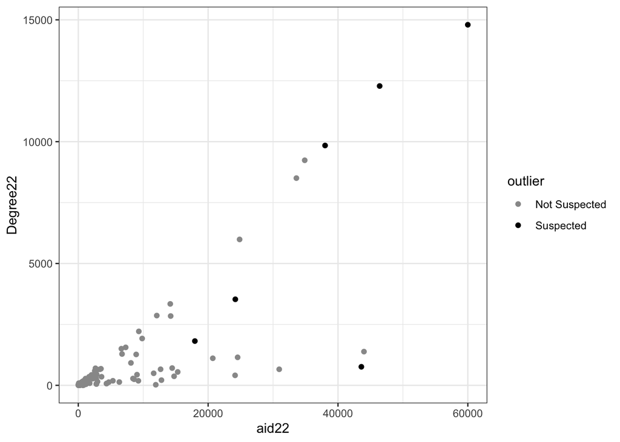

```r
Capstone_22 %>% ggplot(aes(x=aid22, y=degree22, color =outlier))+
  geom_point()+
  scale_color_manual(values = c("#999999","#000000"))+
  labs(x = "aid22", y="Degree22", color="outlier")+
  theme_bw()
```

There are 6 Outliers. (as defined by the residual $\ge 2.5$)

**Suspected influential/leverage points that exist**

```r
library(devtools)
install_github("ieb2/class_package", force = TRUE)
```

[output not shown]

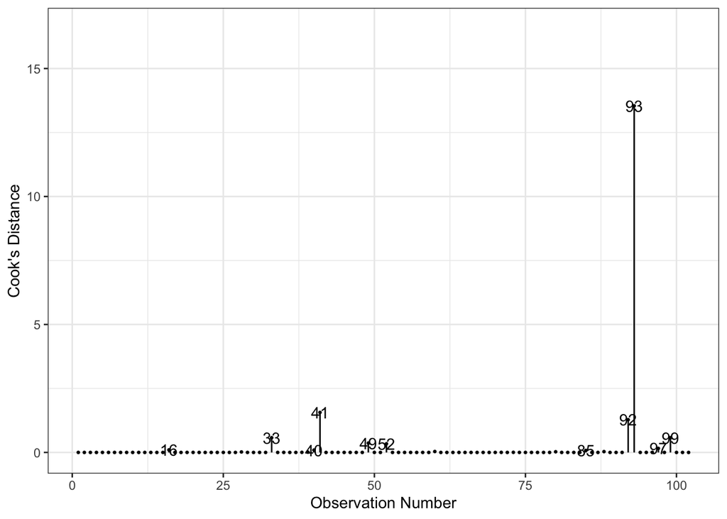

```r
library(classpackage)

cooks(m3)
```

**Stating if multicollinearity is a problem in this model**

```r
library(car)
vif(m3)
```

```
      aid22     loans22 library2022
   2.794687    2.624924    1.106125
```

VIF is not greater than 10 on any predictors. Thus, No multicollinearity is present.

**Assumptions on the linear model**

```r
m4 <- lm(degree22~aid22+loans22+library2022, data=Capstone_22)

summary(m4)$adj.r.squared
```

```
[1] 0.7354386
```

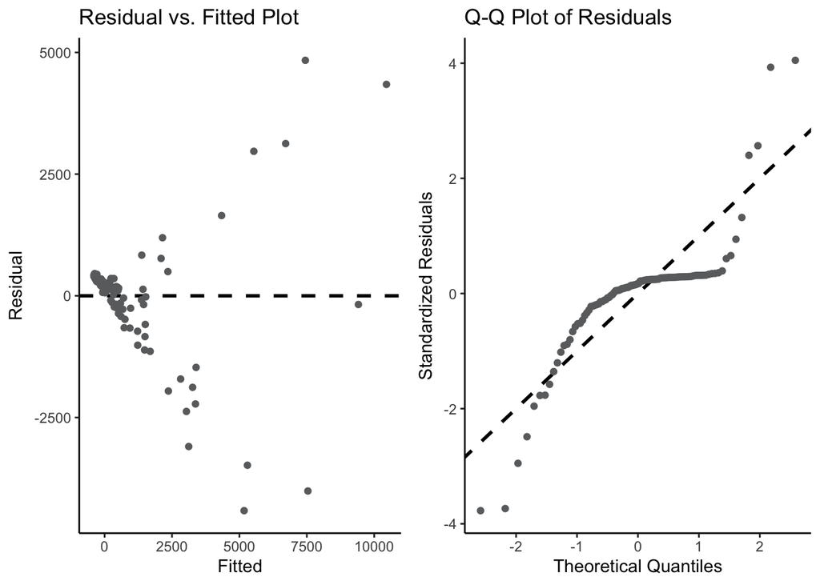

```r
anova_check(m4)
```

```r
library(dplyr)
library(tidyr)

Capstone_rate <- Capstone %>%
  select(rate2022, rate2021, rate2020, rate2019, rate2018) %>%
  na.omit()


colMeans(Capstone_rate, na.rm=TRUE)
```

```
rate2022 rate2021 rate2020 rate2019 rate2018
48.28713 49.39604 50.35644 47.71287 46.54455
```

```r
df_rate <- Capstone_rate %>%
  pivot_longer(cols = c(`rate2022`, `rate2021`, `rate2020`, `rate2019`, `rate2018`),
               names_to = "year", values_to = "rates")


df_rate <- df_rate %>%
  mutate(Period = case_when(
    year %in% c("rate2018", "rate2019") ~ "PreCOVID",
    year %in% c("rate2020", "rate2021") ~ "During COVID",
    TRUE ~ "Post Covid"
  ))


anova_result1 <- aov(rates ~ Period, data = df_rate)
summary(anova_result1)
```

```
             Df Sum Sq Mean Sq F value Pr(>F)
Period        2    766   383.1    1.03  0.358
Residuals   502 186793   372.1
```

```r
TukeyHSD(anova_result1)
```

```
  Tukey multiple comparisons of means
    95% family-wise confidence level

Fit: aov(formula = rates ~ Period, data = df_rate)

$Period
                             diff       lwr      upr     p adj
Post Covid-During COVID -1.589109 -7.115071 3.936854 0.7775809
PreCOVID-During COVID   -2.747525 -7.259454 1.764405 0.3254943
PreCOVID-Post Covid     -1.158416 -6.684378 4.367547 0.8747872
```

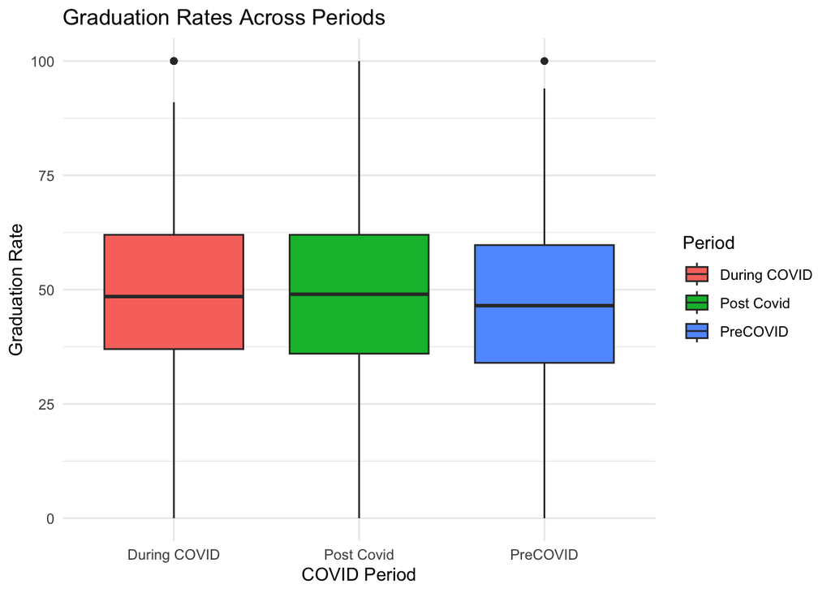

```r
ggplot(df_rate, aes(x = Period, y = rates, fill = Period)) +
  geom_boxplot() +
  labs(title = "Graduation Rates Across Periods",
       x = "COVID Period",
       y = "Graduation Rate") +
  theme_minimal()
```

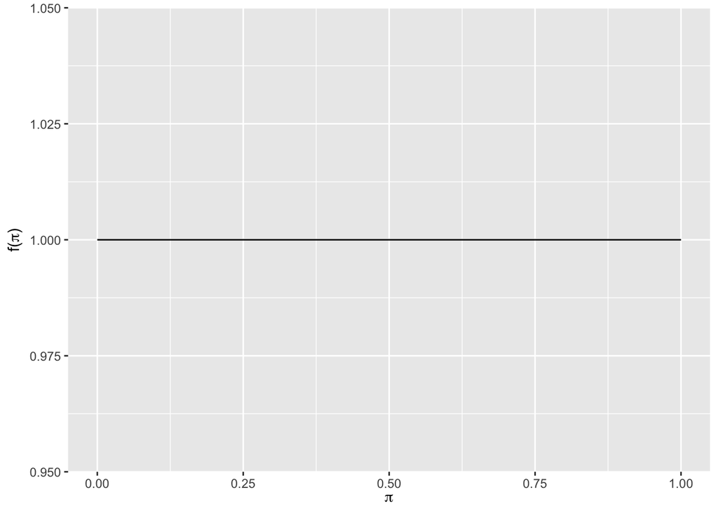

```r
library(bayesrules)

Bayes <- read.csv("/Users/andeegarcia/Desktop/DATASCIENCE2/alldata.csv")

Bayes2 <- Bayes %>% select(degree22, degree2021, degree2020, degree2019, degree2018, Enrollment21, Enrollment20, Enrollment19, Enrollment18, Enrollment17)



plot_beta(1,1)
```

```r
colSums(Bayes2, na.rm=TRUE)
```

```
    degree22   degree2021   degree2020   degree2019   degree2018 Enrollment21
      111511       112693       108600       104658       100846       839625
Enrollment20 Enrollment19 Enrollment18 Enrollment17
      865618       893203       892620       890002
```

```r
summarize_beta_binomial(1,1, 100846/1000, (100846/.4654455)/1000)      #2018 rates
```

```
      model   alpha     beta      mean      mode         var         sd
1     prior   1.000   1.0000 0.5000000       NaN 0.083333333 0.28867513
2 posterior 101.846 116.8195 0.4657615 0.4654455 0.001132757 0.03365646
```

```r
summarize_beta_binomial(101.846, 116.8195, 104658/1000, (104658/.4771287)/1000)    #2019 rates
```

```
      model   alpha     beta      mean      mode          var         sd
1     prior 101.846 116.8195 0.4657616 0.4654456 0.0011327575 0.03365646
2 posterior 206.504 231.5111 0.4714540 0.4713231 0.0005676003 0.02382436
```

```r
summarize_beta_binomial(206.504, 231.5111, 108600/1000, (108600/.5035644)/1000)  #2020 rates
```

```
      model   alpha     beta      mean      mode          var         sd
1     prior 206.504 231.5111 0.4714541 0.4713231 0.0005676004 0.02382436
2 posterior 315.104 338.5737 0.4820480 0.4819929 0.0003813750 0.01952883
```

```r
summarize_beta_binomial(315.104, 338.5737, 112693/1000, (112693/.4939604)/1000)    #2021 rates
```

```
      model   alpha     beta      mean      mode          var         sd
1     prior 315.104 338.5737 0.4820480 0.4819929 0.0003813750 0.01952883
2 posterior 427.797 454.0225 0.4851299 0.4850961 0.0002829331 0.01682062
```

```r
summarize_beta_binomial(427.797, 454.0225, 111511/1000, (111511/.4828713)/1000)   #2022 rates
```

```
      model   alpha     beta      mean      mode          var         sd
1     prior 427.797 454.0225 0.4851299 0.4850961 0.0002829331 0.01682062
2 posterior 539.308 573.4447 0.4846612 0.4846335 0.0002242551 0.01497515
```

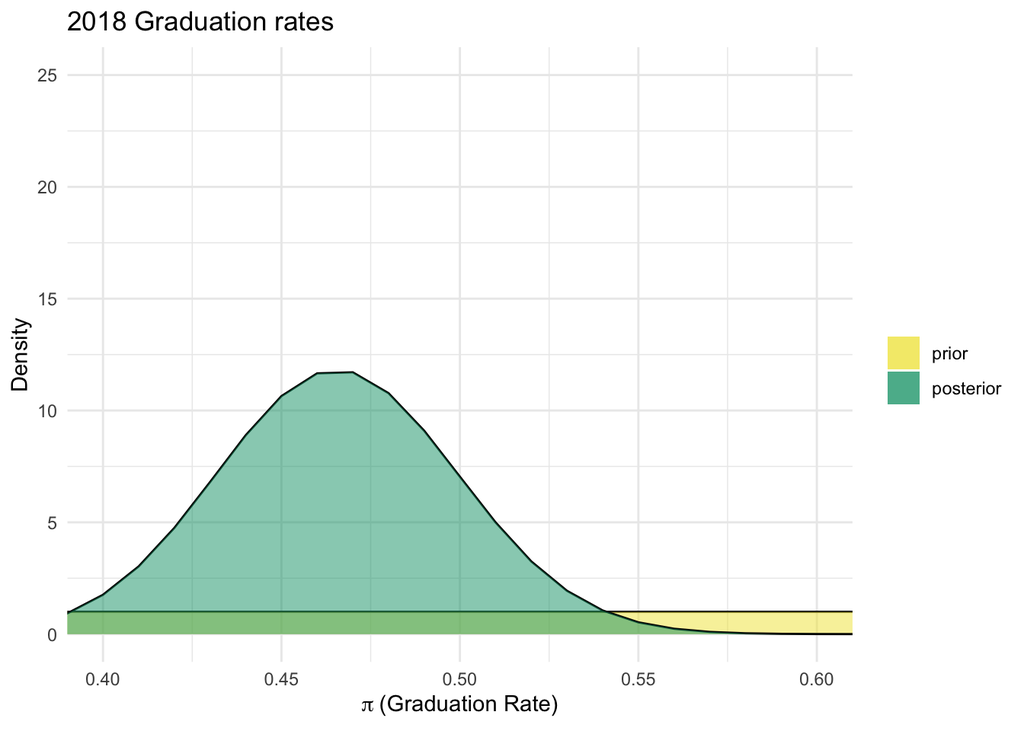

```r
# Posterior Probability (539.308,573.4447) with a 48.5% Mean

plot_beta_binomial(1,1, 100846/1000, (100846/.4654455)/1000) + coord_cartesian(xlim = c(0.4, 0.6), (ylim= c(0,25))) +
  labs(x = expression(pi~"(Graduation Rate)"), y = "Density") +
  theme_minimal() + ggtitle("2018 Graduation rates")
```

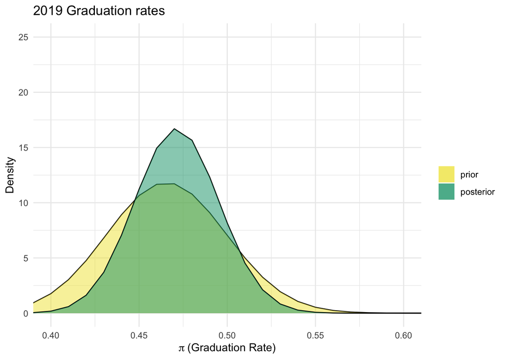

```r
plot_beta_binomial(101.846, 116.8195, 104658/1000, (104658/.4771287)/1000) + coord_cartesian(xlim = c(0.4, 0.6), (ylim= c(0,25))) +
  labs(x = expression(pi~"(Graduation Rate)"), y = "Density") +
  theme_minimal() + ggtitle("2019 Graduation rates")
```

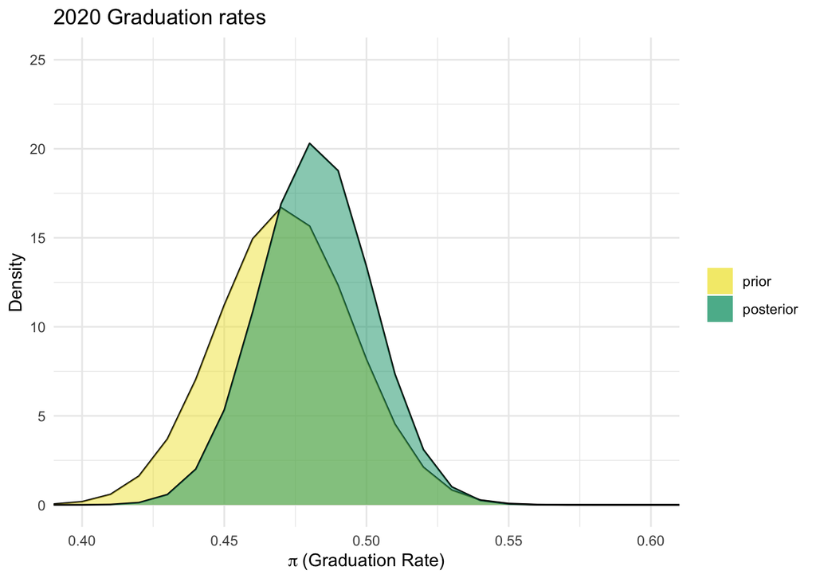

```r
plot_beta_binomial(206.504, 231.5111, 108600/1000, (108600/.5035644)/1000) + coord_cartesian(xlim = c(0.4, 0.6), (ylim= c(0,25))) +
  labs(x = expression(pi~"(Graduation Rate)"), y = "Density") +
  theme_minimal() + ggtitle("2020 Graduation rates")
```

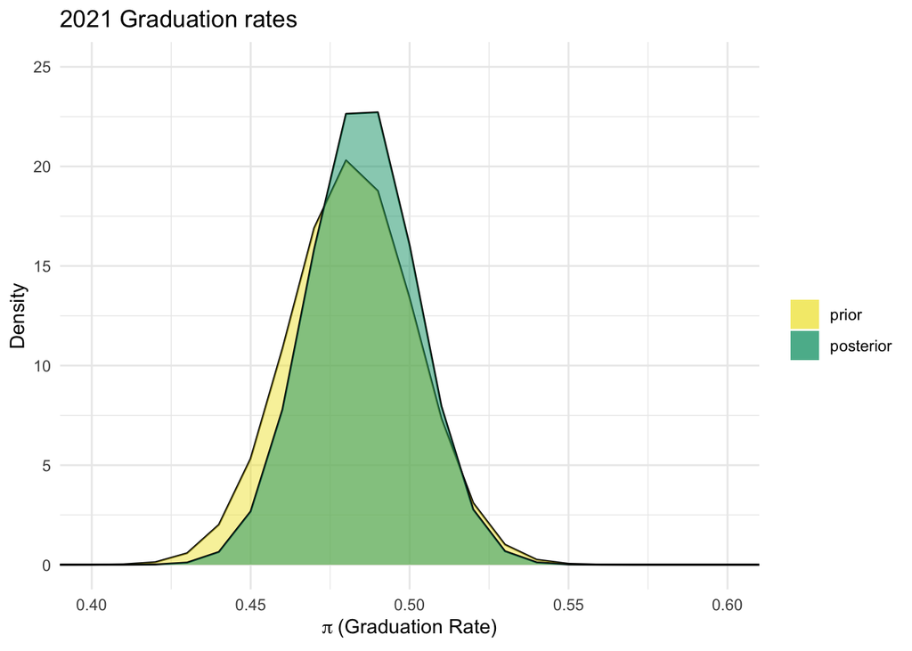

```r
plot_beta_binomial(315.104, 338.5737, 112693/1000, (112693/.4939604)/1000) + coord_cartesian(xlim = c(0.4, 0.6), (ylim= c(0,25))) +
  labs(x = expression(pi~"(Graduation Rate)"), y = "Density") +
  theme_minimal() +  ggtitle("2021 Graduation rates")
```

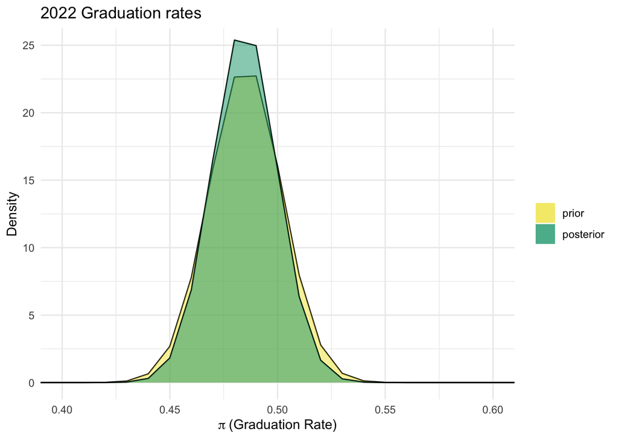

```r
plot_beta_binomial(427.797, 454.0225, 111511/1000, (111511/.4828713)/1000) + coord_cartesian(xlim = c(0.4, 0.6), (ylim= c(0,25))) +
  labs(x = expression(pi~"(Graduation Rate)"), y = "Density") +
  theme_minimal() +  ggtitle("2022 Graduation rates")
```